# Homeworksheet 1

Jeffrey A. Walker

8/31/2021

Learning goals: Project organization

# Project Organization

The goal is to create and organize a BIO 413/513 project folder that has the same organization, including the same sub-folder names and data file names, as my project folder. By doing this, I can run your .Rmd files without changing anything. Your .Rmd folder is completely portable! Yaaaay

The organization scheme is in chapter 2 of the textbook. Here is more information.

You Project folder should contain the subfolder named “data”. We will analyze many datasets in this class and each of these datasets is from a different research paper. To keep this organized, each data file (or all the data files from a single paper) will be stored in its own “data from” folder within the data folder. **IMPORTANT**: The name of the data-from folder containing the data files from a specific paper should be the title of the paper. The data folder should look like this after downloading the data file for homeworksheet 1 and creating the data-from folder “Coupling of bone resorption and formation by RANKL reverse signalling”:

[figure not shown]

Every assignment will follow the same process. You will

1. download one or more data files
2. create a data-from folder with the name equal to title of the paper
3. move the data file into the new, data-from folder.

If mutiple data files come from the same paper, you need to create only a single data-from folder to house these. If each data file comes from a different paper, you need to create a separate data-from folder for each.

After homeworksheet 2, which has 3 data files to download, each from a different paper, your data folder should look like this.

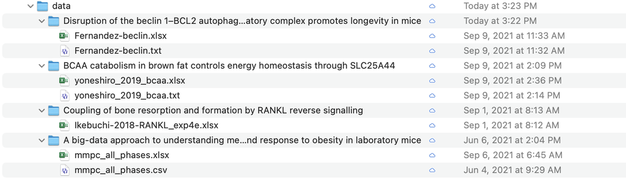

```r
image_path <- here::here("images/data_folder_after_hws2.png")
knitr::include_graphics(image_path)
```

# This homework

In **homework 1**, you will create a .Rmd file with all the code chunks below. Knit the document. Send me the .Rmd file *and* the .html file. The chunks will only work properly if you’ve set up your directory as specified in Chapter 2.

**Where is the data file?** – the data file is in the module “data”. In your project folder, you will need to 1) create a new subdirectory within the “data” directory. The name of the subdirectory must be the name of the paper (because this is what the code reads), which is “Coupling of bone resorption and formation by RANKL reverse signalling”. Then, make sure the data file that you downloaded is inside this subdirectory that you created.

**Windows issues with the names of files**. Windows files have extensions like .xlsx that are hidden when you look at the file. But this extension is a critical part of the filename. When you copy a file name to paste into your script, you need to copy the whole name including this extension.

**How to see the code** – click on the “code” buttons to see a code chunk. You should be able to copy and paste directly from this chunk into your own script.

**How to knit to html** – click on the little arrow next to the “Knit” button in the header bar of your script pane and choose “Knit to html” in the popup menu. I think going forward, if you click “Knit” and not the little popup menu triangle, then you will output to html only.

If you haven’t installed these packages, then do it now. Remember, you only install once.

# Setup

```r
knitr::opts_chunk$set(echo = TRUE)

# import and wrangling
library(readxl)
library(data.table)
library(magrittr)
library(here)

# analysis
library(emmeans)

# tables and figures
library(ggplot2)
library(ggpubr)
library(knitr)
library(kableExtra)

source_path <- here("R/ggplot_the_model.R")
source(source_path)
here <- here::here

data_folder <- "data"
```

# About the data

Data file name: Ikebuchi-2018-RANKL_exp4e.xlsx

Source article: [Ikebuchi, Yuki, Shigeki Aoki, Masashi Honma, Madoka Hayashi, Yasutaka Sugamori, Masud Khan, Yoshiaki Kariya et al. “Coupling of bone resorption and formation by RANKL reverse signalling.” Nature 561, no. 7722 (2018): 195-200.](https://www.nature.com/articles/s41586-018-0482-7)

Experiment background: Bone remodeling involves the removal of old bone matrix by osteoclasts and the secretion of new bone matrix by osteoblasts. The *RANKL* [is a gene encoding a protein that regulates bone remodeling and health](https://en.wikipedia.org/wiki/RANKL) and is a common focus of study in several labs at [MMCRI](https://mmcri.org/?page_id=19610). The researchers designed the experiment in Fig 4e to measure the effect of an engineered mutation in the RANKL gene on bone remodeling and formation. The response variable in Fig 4e is the mineral apposition rate, [which is a measure of the rate of new bone matrix deposition](https://www.scielo.br/j/abem/a/y6YzmC97fwFv9TxCSR3xpcS/?lang=en&format=html). The researchers compared this rate between mice with the mutated RANKL gene and wildtype mice without the mutated gene.

Experiment design

# Import the data

```r
# create directory path
file_folder <- "Coupling of bone resorption and formation by RANKL reverse signalling"
file_in <- "Ikebuchi-2018-RANKL_exp4e.xlsx"
file_path <- here(data_folder, file_folder, file_in)
```

```r
# the range argument isn't necessary since the excel sheet is tidy
# the col_names argument isn't necessary since TRUE is the default
exp4e <- read_excel(file_path,
                    sheet = "fig4e",
                    range = "A1:B17", # not necessary
                    col_names = TRUE) %>% # not necessary
  data.table()

# relevel treatment levels

treatment_levels <- c("WT", "RANKL_p29A")

exp4e[, treatment := factor(treatment,
                            levels = treatment_levels)]
# View(exp4e)
```

# Analyze the data

We are fitting a linear model that is equivalent to a t-test that you learned in MAT 220

1. Fit the model

```r
m1 <- lm(mar ~ treatment, data = exp4e)
```

2. compute the coefficients of the model

```r
m1_coef <- cbind(
  coef(summary(m1)),
  confint(m1)
)
```

3. compute the modeled means

```r
m1_emm <- emmeans(m1, specs = "treatment")
```

4. compute the contrasts

```r
m1_pairs <- contrast(m1_emm,
                     method = "revpairwise") %>%
  summary(infer = TRUE)
```

# Some output for our report

## Table of model coefficients

```r
m1_coef %>%
  kable(digits = c(2,3,1,8,2,2),
        caption = "Coefficients of the model m1 fit to the data from experiment 4e.") %>%
  kable_styling()
```

Coefficients of the model m1 fit to the data from experiment 4e.

|  | Estimate | Std. Error | t value | Pr(>\|t\|) | 2.5 % | 97.5 % |
| --- | --- | --- | --- | --- | --- | --- |
| (Intercept) | 3.45 | 0.031 | 111.7 | 0 | 3.38 | 3.52 |
| treatmentRANKL_p29A | -0.65 | 0.044 | -15.0 | 0 | -0.75 | -0.56 |

## Table of modeled means

```r
m1_emm %>%
  summary() %>%
  kable(digits = c(1,2,3,1,2,2),
        caption = "Modeled means of exp4e.") %>%
  kable_styling()
```

Modeled means of exp4e.

| treatment | emmean | SE | df | lower.CL | upper.CL |
| --- | --- | --- | --- | --- | --- |
| WT | 3.45 | 0.031 | 14 | 3.38 | 3.52 |
| RANKL_p29A | 2.80 | 0.031 | 14 | 2.73 | 2.86 |

## Table of contrasts

```r
m1_pairs %>%
  kable(digits = c(1,2,3,1,2,2,1,5),
        caption = "Estimated effect of RANKL mutation on mineral apposition rate (mar).") %>%
  kable_styling()
```

Estimated effect of RANKL mutation on mineral apposition rate (mar).

| contrast | estimate | SE | df | lower.CL | upper.CL | t.ratio | p.value |
| --- | --- | --- | --- | --- | --- | --- | --- |
| RANKL_p29A - WT | -0.65 | 0.044 | 14 | -0.75 | -0.56 | -15 | 0 |

## A figure

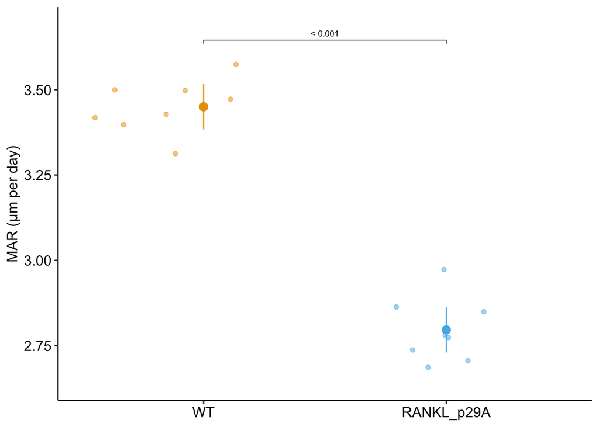

```r
ggplot_the_response(m1,
                    m1_emm,
                    m1_pairs,
                    y_label = "MAR (µm per day)")
```